# Bayesian Linear Regression in R

Simon Thornewill von Essen

12/19/2019

We can use linear regression in R in order to perform bayesian linear regression.

```r
oring <- read.table("http://www.randomservices.org/random/data/Challenger2.txt",
                    header = TRUE)

attach(oring)
head(oring)
```

```
##    T  I
## 1 53 11
## 2 57  4
## 3 58  4
## 4 63  2
## 5 66  0
## 6 67  0
```

The dataset that was just imported was the o-ring damage indices for the challenger 2 launch failure. The higher I is, the more damage was incurred on the ring.

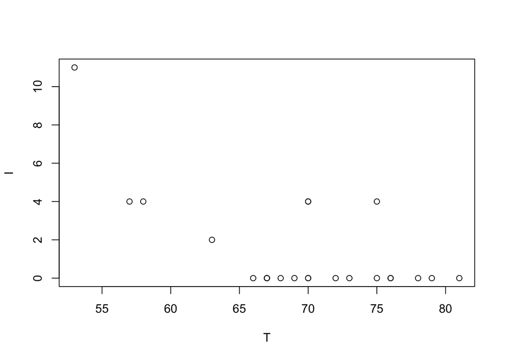

```r
plot(T, I)
```

We can see that there is a rough linear relationship between the temperature, T, and the damage index I.

We can create a linear regression like so…

```r
oring.lm <- lm(I~T)

summary(oring.lm)
```

```
##
## Call:
## lm(formula = I ~ T)
##
## Residuals:
##     Min      1Q  Median      3Q     Max
## -2.3025 -1.4507 -0.4928  0.7397  5.5337
##
## Coefficients:
##             Estimate Std. Error t value Pr(>|t|)
## (Intercept) 18.36508    4.43859   4.138 0.000468 ***
## T           -0.24337    0.06349  -3.833 0.000968 ***
## ---
## Signif. codes:  0 '***' 0.001 '**' 0.01 '*' 0.05 '.' 0.1 ' ' 1
##
## Residual standard error: 2.102 on 21 degrees of freedom
## Multiple R-squared:  0.4116, Adjusted R-squared:  0.3836
## F-statistic: 14.69 on 1 and 21 DF,  p-value: 0.0009677
```

We can see here that for each increase in T we get a -.24 index of damage, explaining 41% of the variance.

## Given the data, what is the 95% posterior probability of the slope?

```r
-0.24337 - 0.06349*qt(0.975, 21)
```

```
## [1] -0.3754047
```

```r
-0.24337 + 0.06349*qt(0.975, 21)
```

```
## [1] -0.1113353
```

This ends up becoming a posterior distribution because we multiply the error by the prior, which is a t-distribution.

Since this interval does not include zero, that should be good eviedence to support the hypothesis that there is negative o-ring damage as the temperature of the o-rings increases.

## For a given temp, whats the failure index

```r
18.36508 - 0.24337 * 31
```

```
## [1] 10.82061
```

However, sometimes we also would like an interval, we can do this like so…

```r
predict(oring.lm,
        data.frame(T=31),
        interval = "predict")
```

```
##        fit      lwr      upr
## 1 10.82052 4.048269 17.59276
```

We can also calculate this manually. Note that we need to multiply by a scale factor:

$$\sqrt{1 + \frac{1}{n} + \frac{(x^*-\bar{x})^2}{(n-1)s_x^2}}$$

```r
10.82052 - 2.102*qt(0.975, 21)*sqrt(1 + 1/23 + ((31-mean(T))^2/22/var(T)))
```

```
## [1] 4.047169
```

```r
10.82052 + 2.102*qt(0.975, 21)*sqrt(1 + 1/23 + ((31-mean(T))^2/22/var(T)))
```

```
## [1] 17.59387
```

We can even use this to calculate probabilistic statements of failure given a certain point.

```r
1 - pt((0 - 10.82061)/(2.102*sqrt(1 + 1/length(T) +
                                    ((31-mean(T))^2/(length(T)-1)/var(T)))),
       21)
```

```
## [1] 0.9983814
```

However, doing this analytically is kind of tedious, normally we have packages that are able to calculate these things for us such as JAGS in R or PyMC/Pyro in python.